# Communicate Data Findings - Pisa 2012 Results Data

> Next I want to take another look at textbook possession, with a pairwise plot of subject scores and wealth.

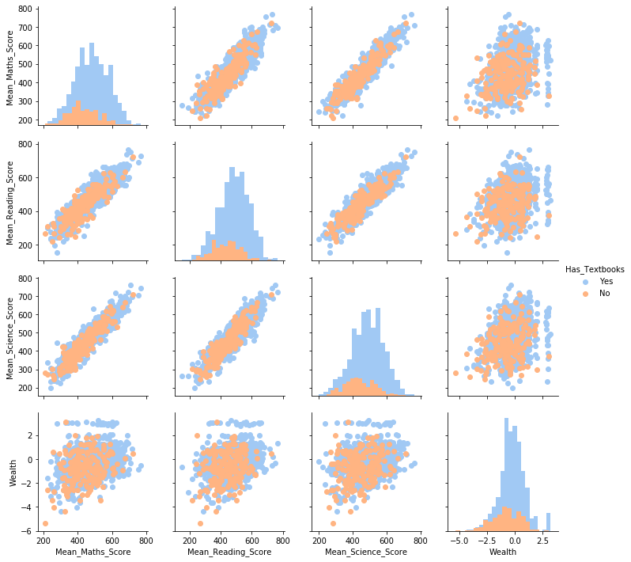

```python
# plot matrix: sample 1000 students so that plots are clearer and
# they render faster
samples = np.random.choice(df.shape[0], 1000, replace = False)
student_samp = df.loc[samples,:]

# plot pairwise correlation of wealth and maths mean score, seperated by has_textbooks feature
# using hue parameter
g = sb.PairGrid(data = student_samp, vars = numeric_vars, hue='Has_Textbooks', palette="pastel")
g = g.map_diag(plt.hist, bins = 20)
g.map_offdiag(plt.scatter)
g = g.add_legend();
```

> Here we again find the expected correlation between textbook possession and score, but only a very weak correlation of wealth and textbook possession. There doesn’t seem to be enough here to follow up on.

> Finally for this section, I want to look at how textbook possession is correlated to the scores of all three subjects, in relation to the gender of the students.

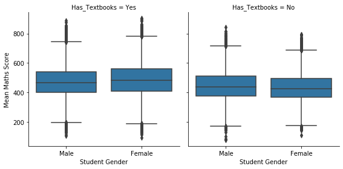

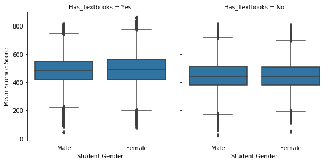

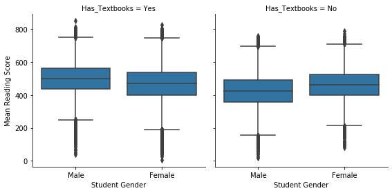

```python
# create FacetGrid boxplots of, gender split of students with/without textbooks,
# for each of the three mean score types

g = sb.FacetGrid(data = df, col = 'Has_Textbooks', height =4)
g.map(sb.boxplot, 'Gender', 'Mean_Maths_Score', color = base_colour)
g.set_xlabels('Student Gender')
g.set_ylabels('Mean Maths Score')

g = sb.FacetGrid(data = df, col = 'Has_Textbooks', height =4)
g.map(sb.boxplot, 'Gender', 'Mean_Science_Score', color = base_colour)
g.set_xlabels('Student Gender')
g.set_ylabels('Mean Science Score')

g = sb.FacetGrid(data = df, col = 'Has_Textbooks', height =4)
g.map(sb.boxplot, 'Gender', 'Mean_Reading_Score', color = base_colour)
g.set_xlabels('Student Gender')
g.set_ylabels('Mean Reading Score');
```

> We find some interesting results here. There seems to be a correlation of textbook possession, gender of students, and the corresponding score of the three subjects. Female students see a greater increase of scores, compared to male students, in mathematics and science if they have textbooks. Male students improve their reading scores more than females if they are in possession of textbooks.

### Multivariate relationships observed.

> The multivariate exploration confirmed some of my earlier findings, but also gave insights to other effects which were of interest to me.

> I found OECD membership is not only correlated to a country’s maths score, but also provides a good indicator of a country’s wealth.

> Truancy appeared to be correlated to scores and not wealth as I had thought.

> Some countries were found to buck the trend of gender in relation to score achieved across the three subjects. Female students were found to outperforming male students in mathematics and science in some countries. However, this may also have been in part to male students underperforming in those countries.

### Surprising interaction of features.

> There seems to be a correlation of text book possession, gender of students, and the corresponding score of the three subjects. In mathematics and science, female students have a greater increase of scores, than male students, if they have textbooks, and male students improve their reading scores more than females if they are in possession of textbooks.

**References and Citations**

Pisa 2012 Datafile - https://www.google.com/url?q=https://s3.amazonaws.com/udacity-hosted-downloads/ud507/pisa2012.csv.zip&sa=D&ust=1554482573645000

$^{1}$Pisa 2012 Data Dictionary - https://www.google.com/url?q=https://docs.google.com/spreadsheet/ccc?key%3D0AllIqIyvWZdadDd5NTlqZ1pBMHlsUjdrOTZHaVBuSlE%26usp%3Dsharing&sa=D&ust=1554486256024000

Pisa 2012 Results in Focus Publication - https://www.oecd.org/pisa/data/pisa2012technicalreport.htm

$^{2}$What is an OECD? - https://www.economist.com/the-economist-explains/2017/07/05/what-is-the-oecd

Opening Latin encoded Pisa CSV datafile - Udacity Knowledge

Display all columns of a Pandas DataFrame - https://stackoverflow.com/questions/47022070/display-all-dataframe-columns-in-a-jupyter-python-notebook/47022213

Rename multiple column names in pandas DataFrame - https://chrisalbon.com/python/data_wrangling/pandas_rename_multiple_columns/

Visualise distributions of multiple variables - http://cmdlinetips.com/2019/02/how-to-make-histogram-in-python-with-pandas-and-seaborn/

Annotate single point in scatter plot with text - https://www.pythonmembers.club/2018/05/08/matplotlib-scatter-plot-annotate-set-text-at-label-each-point/

Scatter plot crosshairs for matplotlib - https://fcpython.com/visualisation/scatter-plots-crosshairs-in-matplotlib

Faceted heatmap - Udacity 'Diamonds' Example Project